# Matplotlib is the most commonly used package for plotting in Python

## 1. A simple line chart in Python

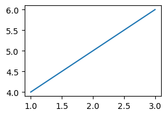

```python
import matplotlib.pyplot as plt

fig = plt.figure(figsize=(3,2), facecolor='white')  # Size, Background color
# The fig here is a handle of the figure. It can be used to make some adjustment
plt.plot([1, 2, 3], [4, 5, 6])
plt.show()
```

## 2. Add x-Label and y-Label to the figure

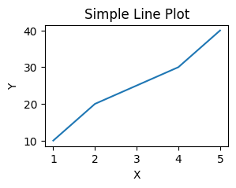

```python
import matplotlib.pyplot as plt

x = [1, 2, 3, 4, 5]
y = [10, 20, 25, 30, 40]

fig = plt.figure(figsize=(3,2), facecolor='white')
plt.plot(x, y)
plt.title('Simple Line Plot')
plt.xlabel('X')
plt.ylabel('Y')
plt.show()
```

## 3. Select a plotting style supported in matplotlib

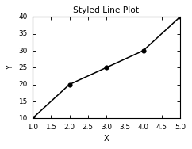

```python
plt.style.use('seaborn-v0_8-paper') # this just need to set once.
fig = plt.figure(figsize=(3,2), facecolor='white')
plt.plot(x, y, 'o-', color='black')
plt.title('Styled Line Plot')
plt.xlabel('X')
plt.ylabel('Y')
plt.show()
```

## 3.1 Show all supported styles in matplotlib

```python
import pandas as pd
allStyles = plt.style.available
# Convert to dataframe for better visualization.
allstyles_df = pd.DataFrame(allStyles, columns=['Style'])
allstyles_df
```

|  | Style |
| --- | --- |
| 0 | Solarize_Light2 |
| 1 | _classic_test_patch |
| 2 | _mpl-gallery |
| 3 | _mpl-gallery-nogrid |
| 4 | bmh |
| 5 | classic |
| 6 | dark_background |
| 7 | fast |
| 8 | fivethirtyeight |
| 9 | ggplot |
| 10 | grayscale |
| 11 | seaborn-v0_8 |
| 12 | seaborn-v0_8-bright |
| 13 | seaborn-v0_8-colorblind |
| 14 | seaborn-v0_8-dark |
| 15 | seaborn-v0_8-dark-palette |
| 16 | seaborn-v0_8-darkgrid |
| 17 | seaborn-v0_8-deep |
| 18 | seaborn-v0_8-muted |
| 19 | seaborn-v0_8-notebook |
| 20 | seaborn-v0_8-paper |
| 21 | seaborn-v0_8-pastel |
| 22 | seaborn-v0_8-poster |
| 23 | seaborn-v0_8-talk |
| 24 | seaborn-v0_8-ticks |
| 25 | seaborn-v0_8-white |
| 26 | seaborn-v0_8-whitegrid |
| 27 | tableau-colorblind10 |

## 4. Choose different markers and line styles

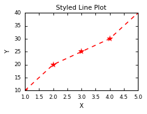

```python
fig = plt.figure(figsize=(3,2), facecolor='white')
plt.plot(x, y, '*--', color='red', markersize=10) # see 4.1 for more details about markers and line styles
plt.title('Styled Line Plot')
plt.xlabel('X')
plt.ylabel('Y')
plt.show()
```

## 4.1 Markers and line styles in plot

### 1. Line Style

#### The second part of the shorthand 'o-' represents the line style. Some common line styles include:

```
'-': Solid line
'--': Dashed line
'-.': Dash-dot line
':': Dotted line
'': No line (used to only show markers)
```

### 2. Markers

#### The first part, 'o', is the marker symbol. matplotlib supports many types of markers:

```
'o': Circle marker
'.': Point marker
',': Pixel marker
'x': X marker
'+': Plus marker
'v': Triangle down marker
'^': Triangle up marker
'<': Triangle left marker
'>': Triangle right marker
's': Square marker
'p': Pentagon marker
'*': Star marker
'h': Hexagon1 marker
'H': Hexagon2 marker
'D': Diamond marker
'd': Thin diamond marker
'|': Vertical line marker
'_': Horizontal line marker
```

## 5. Set range of x and y axis

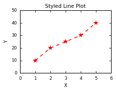

```python
fig = plt.figure(figsize=(3,2), facecolor='white')
plt.plot(x, y, '*--', color='red', markersize=10)
plt.xlim(0, 6)  # Set the range from 0 to 6
plt.ylim(0, 50)  # Set the range from 0 to 50
plt.title('Styled Line Plot')
plt.xlabel('X')
plt.ylabel('Y')
plt.show()
```

## 6. Change fontsize for the whole figure

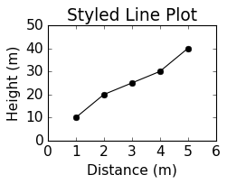

```python
# Update the default font size for the entire figure
# This line need to write before making a plot

# Set the seaborn style to classic.
# Using "seaborn-v0_8-paper" will override the setting of fontsize
plt.style.use('classic')

# Update the font size after setting the style
plt.rcParams.update({'font.size': 14})

fig = plt.figure(figsize=(3,2), facecolor='white')

plt.plot(x, y, 'o-', color='black', markersize=6)
plt.xlim(0, 6)  # Set the range from 0 to 6
plt.ylim(0, 50)  # Set the range from 0 to 50
plt.title('Styled Line Plot')
plt.xlabel('Distance (m)') # using meaningful label will make it more clear
plt.ylabel('Height (m)')
plt.show()
```

## 7. set tick width to 2

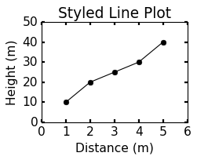

```python
plt.style.use('classic')
plt.rcParams.update({'font.size': 14})
fig = plt.figure(figsize=(3,2), facecolor='white')
plt.plot(x, y, 'o-', color='black', markersize=6)
plt.xlim(0, 6)  # Set the range from 0 to 6
plt.ylim(0, 50)  # Set the range from 0 to 50
plt.title('Styled Line Plot')
plt.xlabel('Distance (m)') # using meaningful label will make it more clear
plt.ylabel('Height (m)')

# Set tick parameters
plt.tick_params(width=2)  # Set tick width to 2
plt.show()
```

## 8. Add grids in the plot

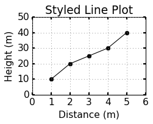

```python
plt.style.use('classic')
plt.rcParams.update({'font.size': 14})
fig = plt.figure(figsize=(3,2), facecolor='white')
plt.plot(x, y, 'o-', color='black', markersize=6)
plt.xlim(0, 6)  # Set the range from 0 to 6
plt.ylim(0, 50)  # Set the range from 0 to 50
plt.title('Styled Line Plot')
plt.xlabel('Distance (m)') # using meaningful label will make it more clear
plt.ylabel('Height (m)')
plt.tick_params(width=2)  # Set tick width to 2
# Add grids
plt.grid(which='both', linestyle=':', linewidth=0.7, color='gray')  # You can customize these parameters

plt.show()
```

## In matplotlib, you can specify colors in various ways. Here are the most common methods for setting colors along with their options:

### 1. Basic Color Names

#### You can use standard color names (e.g., 'red', 'blue', 'green', etc.). Here’s a list of some commonly used color names:

```
'red'
'green'
'blue'
'cyan'
'magenta'
'yellow'
'black'
'white'
'orange'
'purple'
'brown'
'pink'
'gray'
'lightgray'
'darkgray'
```

### 2. Hexadecimal Color Codes

### You can use hex color codes (e.g., '#FF5733' for a shade of red). The format is #RRGGBB where RR, GG, and BB are hexadecimal values for red, green, and blue, respectively.

### 3. RGB and RGBA Tuples

#### Colors can also be specified using RGB or RGBA tuples:

#### RGB: A tuple of three floats representing red, green, and blue, each in the range [0, 1]. For example, (1, 0, 0) for red.

#### RGBA: A tuple of four floats, with the last one representing alpha (opacity). For example, (1, 0, 0, 0.5) for semi-transparent red.

### 4. Grayscale Values

#### You can specify a grayscale value as a string (e.g., '0.5' for medium gray) or as a float in the range [0, 1].

### 5. Colormaps

#### For continuous data, you can use colormaps. matplotlib provides a range of colormaps (e.g., viridis, plasma, cividis, etc.).

## 9. Adjust color in the plot

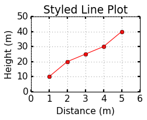

```python
plt.style.use('classic')
plt.rcParams.update({'font.size': 14})
fig = plt.figure(figsize=(3,2), facecolor='white')
plt.plot(x, y, 'o-', color= (1, 0, 0, 1), markersize=6)
# set color using (R,G,B,A) tuple where R is Red, G is Green, B is Blue, A is Alpha. All values range [0,1]

plt.xlim(0, 6)  # Set the range from 0 to 6
plt.ylim(0, 50)  # Set the range from 0 to 50
plt.title('Styled Line Plot')
plt.xlabel('Distance (m)') # using meaningful label will make it more clear
plt.ylabel('Height (m)')
plt.tick_params(width=2)  # Set tick width to 2
# Add grids
plt.grid(which='both', linestyle=':', linewidth=0.7, color='gray')  # You can customize these parameters

plt.show()
```

## 10. Checking Available Colormaps

```python
import matplotlib.cm as cm

from matplotlib import colormaps
df = pd.DataFrame(list(colormaps))
# Calculate the number of elements needed for reshaping
total_elements = 13 * 13  # 169 elements needed
current_elements = df.shape[0]  # Current number of elements (166)

# Pad the DataFrame with NaN values to reach 169 elements
padding_size = total_elements - current_elements  # Calculate padding size
if padding_size > 0:
    # Create a DataFrame with NaN values for padding
    padding = pd.DataFrame([np.nan] * padding_size, columns=['Value'])
    df_padded = pd.concat([df, padding], ignore_index=True)
else:
    df_padded = df

# Confirm the padded DataFrame's length
print(f"\nPadded DataFrame Length: {len(df_padded)}")

# Reshape the padded DataFrame to 13 by 13
reshaped_array = df_padded[0].values.reshape(13, 13)

# Convert the reshaped array back to a DataFrame
reshaped_df = pd.DataFrame(reshaped_array)

# Display the reshaped DataFrame
print("\nReshaped DataFrame (13 by 13):")
reshaped_df
```

```
Padded DataFrame Length: 169

Reshaped DataFrame (13 by 13):
```

|  | 0 | 1 | 2 | 3 | 4 | 5 | 6 | 7 | 8 | 9 | 10 | 11 | 12 |
| --- | --- | --- | --- | --- | --- | --- | --- | --- | --- | --- | --- | --- | --- |
| 0 | magma | inferno | plasma | viridis | cividis | twilight | twilight_shifted | turbo | Blues | BrBG | BuGn | BuPu | CMRmap |
| 1 | GnBu | Greens | Greys | OrRd | Oranges | PRGn | PiYG | PuBu | PuBuGn | PuOr | PuRd | Purples | RdBu |
| 2 | RdGy | RdPu | RdYlBu | RdYlGn | Reds | Spectral | Wistia | YlGn | YlGnBu | YlOrBr | YlOrRd | afmhot | autumn |
| 3 | binary | bone | brg | bwr | cool | coolwarm | copper | cubehelix | flag | gist_earth | gist_gray | gist_heat | gist_ncar |
| 4 | gist_rainbow | gist_stern | gist_yarg | gnuplot | gnuplot2 | gray | hot | hsv | jet | nipy_spectral | ocean | pink | prism |
| 5 | rainbow | seismic | spring | summer | terrain | winter | Accent | Dark2 | Paired | Pastel1 | Pastel2 | Set1 | Set2 |
| 6 | Set3 | tab10 | tab20 | tab20b | tab20c | magma_r | inferno_r | plasma_r | viridis_r | cividis_r | twilight_r | twilight_shifted_r | turbo_r |
| 7 | Blues_r | BrBG_r | BuGn_r | BuPu_r | CMRmap_r | GnBu_r | Greens_r | Greys_r | OrRd_r | Oranges_r | PRGn_r | PiYG_r | PuBu_r |
| 8 | PuBuGn_r | PuOr_r | PuRd_r | Purples_r | RdBu_r | RdGy_r | RdPu_r | RdYlBu_r | RdYlGn_r | Reds_r | Spectral_r | Wistia_r | YlGn_r |
| 9 | YlGnBu_r | YlOrBr_r | YlOrRd_r | afmhot_r | autumn_r | binary_r | bone_r | brg_r | bwr_r | cool_r | coolwarm_r | copper_r | cubehelix_r |
| 10 | flag_r | gist_earth_r | gist_gray_r | gist_heat_r | gist_ncar_r | gist_rainbow_r | gist_stern_r | gist_yarg_r | gnuplot_r | gnuplot2_r | gray_r | hot_r | hsv_r |
| 11 | jet_r | nipy_spectral_r | ocean_r | pink_r | prism_r | rainbow_r | seismic_r | spring_r | summer_r | terrain_r | winter_r | Accent_r | Dark2_r |
| 12 | Paired_r | Pastel1_r | Pastel2_r | Set1_r | Set2_r | Set3_r | tab10_r | tab20_r | tab20b_r | tab20c_r | NaN | NaN | NaN |

## 11. Adding Anotation

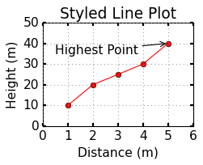

```python
x = [1, 2, 3, 4, 5]
y = [10, 20, 25, 30, 40]
plt.style.use('classic')
plt.rcParams.update({'font.size': 14})
fig = plt.figure(figsize=(3,2), facecolor='white')
plt.plot(x, y, 'o-', color= (1, 0, 0, 1), markersize=6)
# set color using (R,G,B,A) tuple where R is Red, G is Green, B is Blue, A is Alpha. All values range [0,1]

plt.xlim(0, 6)  # Set the range from 0 to 6
plt.ylim(0, 50)  # Set the range from 0 to 50
plt.title('Styled Line Plot')
plt.xlabel('Distance (m)') # using meaningful label will make it more clear
plt.ylabel('Height (m)')
plt.tick_params(width=2)  # Set tick width to 2
# Add grids
plt.grid(which='both', linestyle=':', linewidth=0.7, color='gray')  # You can customize these parameters
plt.annotate('Highest Point', xy=(5, 40), xytext=(0.5, 35),
             arrowprops=dict(facecolor='black', arrowstyle='->'))
plt.show()
```

## 12. Save the figure before plt.show()

- Use bbox_inches = 'tight' to in plt.savefig to resolve cutting edge of the png file

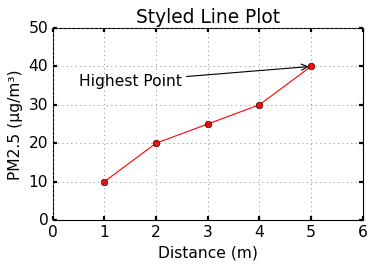

```python
x = [1, 2, 3, 4, 5]
y = [10, 20, 25, 30, 40]
plt.style.use('classic')
plt.rcParams.update({'font.size': 14})
fig = plt.figure(figsize=(5,3), facecolor='white')
plt.plot(x, y, 'o-', color= (1, 0, 0, 1), markersize=6)
# set color using (R,G,B,A) tuple where R is Red, G is Green, B is Blue, A is Alpha. All values range [0,1]

plt.xlim(0, 6)  # Set the range from 0 to 6
plt.ylim(0, 50)  # Set the range from 0 to 50
plt.title('Styled Line Plot')
plt.xlabel('Distance (m)') # using meaningful label will make it more clear
plt.ylabel('PM2.5 (\u03bcg/m\u00b3)')
plt.tick_params(width=2)  # Set tick width to 2
# Add grids
plt.grid(which='both', linestyle=':', linewidth=0.7, color='gray')  # You can customize these parameters
plt.annotate('Highest Point', xy=(5, 40), xytext=(0.5, 35),
             arrowprops=dict(facecolor='black', arrowstyle='->'))
plt.savefig('myplot.png', dpi=300, bbox_inches='tight')
# use bbox_inches = 'tight' to resolve cutting edge of the png file
plt.show()
```

## Lowercase Greek Letters:

### Symbol Name Unicode Escape

```
α   Alpha    \u03b1
β   Beta     \u03b2
γ   Gamma    \u03b3
δ   Delta    \u03b4
ε   Epsilon \u03b5
ζ   Zeta     \u03b6
η   Eta   \u03b7
θ   Theta    \u03b8
ι   Iota     \u03b9
κ   Kappa    \u03ba
λ   Lambda  \u03bb
μ   Mu    \u03bc
ν   Nu    \u03bd
ξ   Xi    \u03be
ο   Omicron \u03bf
π   Pi    \u03c0
ρ   Rho   \u03c1
σ   Sigma    \u03c3
τ   Tau   \u03c4
υ   Upsilon \u03c5
φ   Phi   \u03c6
χ   Chi   \u03c7
ψ   Psi   \u03c8
ω   Omega    \u03c9
```

## Uppercase Greek Letters:

### Symbol Name Unicode Escape

```
Α   Alpha   \u0391
Β   Beta    \u0392
Γ   Gamma   \u0393
Δ   Delta   \u0394
Ε   Epsilon \u0395
Ζ   Zeta    \u0396
Η   Eta \u0397
Θ   Theta   \u0398
Ι   Iota    \u0399
Κ   Kappa   \u039a
Λ   Lambda  \u039b
Μ   Mu  \u039c
Ν   Nu  \u039d
Ξ   Xi  \u039e
Ο   Omicron \u039f
Π   Pi  \u03a0
Ρ   Rho \u03a1
Σ   Sigma   \u03a3
Τ   Tau \u03a4
Υ   Upsilon \u03a5
Φ   Phi \u03a6
Χ   Chi \u03a7
Ψ   Psi \u03a8
Ω   Omega   \u03a9
```

## Superscripts:

### These are characters that appear slightly above the normal line of text. They are typically used for exponents or mathematical notations.

### Symbol Description Unicode Escape

```
⁰   Superscript 0   \u2070
¹   Superscript 1   \u00b9
²   Superscript 2   \u00b2
³   Superscript 3   \u00b3
⁴   Superscript 4   \u2074
⁵   Superscript 5   \u2075
⁶   Superscript 6   \u2076
⁷   Superscript 7   \u2077
⁸   Superscript 8   \u2078
⁹   Superscript 9   \u2079
⁺   Superscript Plus    \u207a
⁻   Superscript Minus   \u207b
⁼   Superscript Equals  \u207c
⁽   Superscript Left Parenthesis    \u207d
⁾   Superscript Right Parenthesis   \u207e
```

## Subscripts:

### These are characters that appear slightly below the normal line of text. They are commonly used in chemical formulas or mathematical indices.

### Symbol Description Unicode Escape

```
₀   Subscript 0 \u2080
₁   Subscript 1 \u2081
₂   Subscript 2 \u2082
₃    Subscript 3    \u2083
₄   Subscript 4 \u2084
₅   Subscript 5 \u2085
₆   Subscript 6 \u2086
₇   Subscript 7 \u2087
₈   Subscript 8 \u2088
₉   Subscript 9 \u2089
₊   Subscript Plus  \u208a
₋   Subscript Minus \u208b
₌   Subscript Equals    \u208c
₍   Subscript Left Parenthesis  \u208d
₎   Subscript Right Parenthesis \u208e
```

## Creating subplots in Matplotlib is a powerful way to display multiple plots in a single figure

## 13. Basic Subplots

### You can create a simple grid of subplots using plt.subplots(). Here's an example with a 2x2 grid:

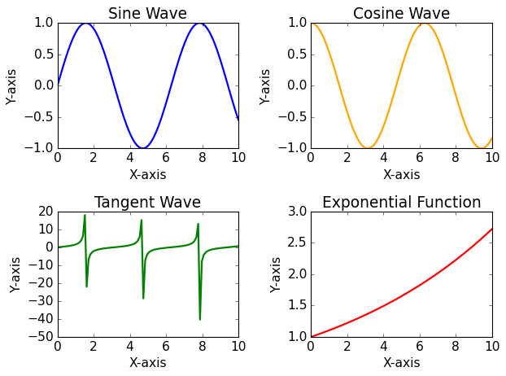

```python
import matplotlib.pyplot as plt
import numpy as np

# Create data
# Sample data
x = np.linspace(0, 10, 100)
y1 = np.sin(x)
y2 = np.cos(x)
y3 = np.tan(x)
y4 = np.exp(x / 10)

# Create a 2x2 grid of subplots
fig, axs = plt.subplots(2, 2, figsize=(8,6),facecolor='white')

# Set the style
plt.style.use('classic')
plt.rcParams.update({'font.size': 14})
# Plot data on each subplot
axs[0, 0].plot(x, y1, color='blue',linewidth=2)
axs[0, 0].set_title('Sine Wave')
axs[0, 0].set_xlabel('X-axis')
axs[0, 0].set_ylabel('Y-axis')

axs[0, 1].plot(x, y2, color='orange',linewidth=2)
axs[0, 1].set_title('Cosine Wave')
axs[0, 1].set_xlabel('X-axis')
axs[0, 1].set_ylabel('Y-axis')

axs[1, 0].plot(x, y3, color='green',linewidth=2)
axs[1, 0].set_title('Tangent Wave')
axs[1, 0].set_xlabel('X-axis')
axs[1, 0].set_ylabel('Y-axis')

axs[1, 1].plot(x, y4, color='red',linewidth=2)
axs[1, 1].set_title('Exponential Function')
axs[1, 1].set_xlabel('X-axis')
axs[1, 1].set_ylabel('Y-axis')

# Adjust layout
plt.tight_layout()
plt.show()
```

## 14. Sharing Axes

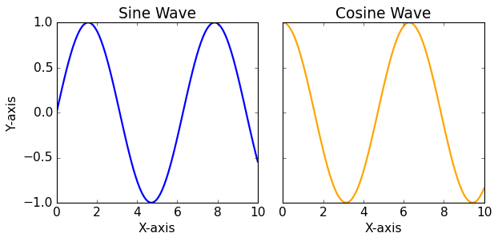

```python
# Create a 1x2 grid of subplots with shared y-axis
fig, axs = plt.subplots(1, 2, sharey=True, figsize=(8,4), facecolor='white')

# Plot data
axs[0].plot(x, y1, color='blue',linewidth=2)
axs[0].set_title('Sine Wave')
axs[0].set_xlabel('X-axis')

axs[1].plot(x, y2, color='orange',linewidth=2)
axs[1].set_title('Cosine Wave')
axs[1].set_xlabel('X-axis')

# Set shared y-label
axs[0].set_ylabel('Y-axis')

# Adjust layout
plt.tight_layout()
plt.show()
```

## 15. Different Plot Types

### You can also mix different types of plots in subplots

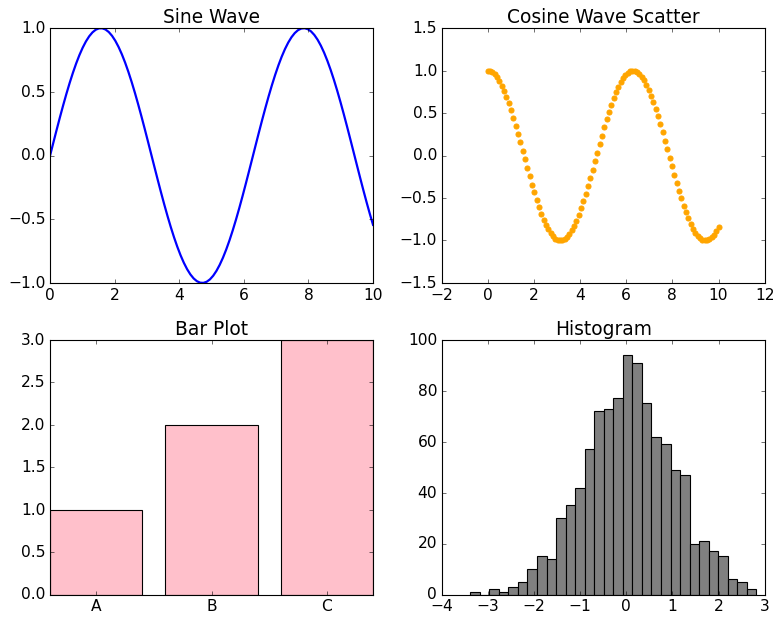

```python
# Create a 2x2 grid of subplots with different plot types
fig, axs = plt.subplots(2, 2, figsize=(10, 8),facecolor='white')

# Line plot
axs[0, 0].plot(x, y1, color='blue',linewidth=2)
axs[0, 0].set_title('Sine Wave')

# Scatter plot
axs[0, 1].scatter(x, y2, color='orange')
axs[0, 1].set_title('Cosine Wave Scatter')

# Bar plot
axs[1, 0].bar(['A', 'B', 'C'], [1, 2, 3], color='pink')
axs[1, 0].set_title('Bar Plot')

# Histogram
axs[1, 1].hist(np.random.randn(1000), bins=30, color='gray')
axs[1, 1].set_title('Histogram')

# Adjust layout
plt.tight_layout()
plt.show()
```

## 16. Another way to create multiple plots in one figure

### Using GridSpec

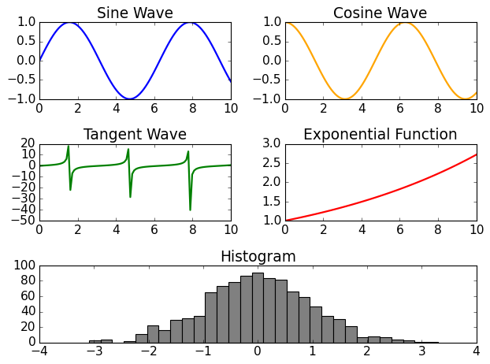

```python
import matplotlib.pyplot as plt
import numpy as np
from matplotlib.gridspec import GridSpec

# Sample data
x = np.linspace(0, 10, 100)
y1 = np.sin(x)  # Sine wave
y2 = np.cos(x)  # Cosine wave
y3 = np.tan(x)  # Tangent wave
y4 = np.exp(x / 10)  # Exponential function

# Create a GridSpec with 3 rows and 2 columns
gs = GridSpec(3, 2)

# Create subplots using GridSpec
fig = plt.figure(figsize=(8,6),facecolor='white')

# Top left: Sine Wave
ax1 = fig.add_subplot(gs[0, 0])
ax1.plot(x, y1, color='blue', linewidth=2)
ax1.set_title('Sine Wave')

# Top right: Cosine Wave
ax2 = fig.add_subplot(gs[0, 1])
ax2.plot(x, y2, color='orange', linewidth=2)
ax2.set_title('Cosine Wave')

# Middle left: Tangent Wave
ax3 = fig.add_subplot(gs[1, 0])
ax3.plot(x, y3, color='green', linewidth=2)
ax3.set_title('Tangent Wave')

# Middle right: Exponential Function
ax4 = fig.add_subplot(gs[1, 1])
ax4.plot(x, y4, color='red', linewidth=2)
ax4.set_title('Exponential Function')

# Bottom: Combine two plots (full width)
ax5 = fig.add_subplot(gs[2, :])  # This subplot spans all columns
ax5.hist(np.random.randn(1000), bins=30, color='gray')
ax5.set_title('Histogram')

# Adjust layout
plt.tight_layout()
plt.show()
```